# Linear Regression

[figure not shown]

به نام خدا

رگرسیون خطی

### فهرست مطالب

- کتاب‌خانه‌ها
- رگرسیون خطی ساده
- رگرسیون خطی چندتایی
- روابط متقابل(interaction terms)
- تبدیل غیرخطی پیش‌بین‌ها

کتاب‌خانه‌ها

در این بخش از دیتافریم‌های موجود در کتابخانه MASS استفاده می‌کنیم.  
دیتافریم Boston : داده‌های جمع‌آوری شده از میانگین قیمت خانه‌های ۵۰۶ محله در اطراف بوستون.  
برای دیدن اطلاعات این دیتافریم و توضیح هر یک از متغیر‌ها کافیست مستندات آن را مطالعه کنید.

```r
install.packages("MASS", repos='http://cran.us.r-project.org')
```

```r
library(MASS)
```

```r
fix(Boston)
names(Boston)
?Boston
```

1. 'crim'

2. 'zn'

3. 'indus'

4. 'chas'

5. 'nox'

6. 'rm'

7. 'age'

8. 'dis'

9. 'rad'

10. 'tax'

11. 'ptratio'

12. 'black'

13. 'lstat'

14. 'medv'

رگرسیون خطی ساده

برای شروع با استفاده از تابع $\texttt{lm()}$ یک مدل ساده‌ی رگرسیون خطی را با medv به عنوان پاسخ(response) و lstat به عنوان پیش‌بین(predictor) بر داده‌ها منطبق می کنیم. سینتکس این کد به صورت $\texttt{lm(response~predictor, data)}$ است.

```r
lm.fit=lm(medv~lstat ,data=Boston)
attach(Boston)
lm.fit=lm(medv~lstat)
```

با تایپ کردن lm.fit برخی اطلاعات اساسی در مورد مدل نشان داده می‌شوند.

```r
lm.fit
```

```
Call:
lm(formula = medv ~ lstat)

Coefficients:
(Intercept)        lstat
      34.55        -0.95
```

برای اطلاعات جزئی‌تر از $\texttt{summary(lm.fit)}$ استفاده ‌می‌کنیم.

```r
summary(lm.fit)
```

```
Call:
lm(formula = medv ~ lstat)

Residuals:
    Min      1Q  Median      3Q     Max
-15.168  -3.990  -1.318   2.034  24.500

Coefficients:
            Estimate Std. Error t value Pr(>|t|)
(Intercept) 34.55384    0.56263   61.41   <2e-16 ***
lstat       -0.95005    0.03873  -24.53   <2e-16 ***
---
Signif. codes:  0 ‘***’ 0.001 ‘**’ 0.01 ‘*’ 0.05 ‘.’ 0.1 ‘ ’ 1

Residual standard error: 6.216 on 504 degrees of freedom
Multiple R-squared:  0.5441,	Adjusted R-squared:  0.5432
F-statistic: 601.6 on 1 and 504 DF,  p-value: < 2.2e-16
```

با استفاده از تابع $\texttt{names()}$ می‌توانیم بقیه اطلاعاتی که در lm.fit ذخیره‌ شده‌اند ببینیم.

```r
names(lm.fit)
```

1. 'coefficients'

2. 'residuals'

3. 'effects'

4. 'rank'

5. 'fitted.values'

6. 'assign'

7. 'qr'

8. 'df.residual'

9. 'xlevels'

10. 'call'

11. 'terms'

12. 'model'

مقادیر مختلف را می‌توان با اسم‌شان به صورت زیر مشاهده کرد.

```r
lm.fit$coefficients
```

**(Intercept)**

34.5538408793831

**lstat**

-0.95004935375799

اما استفاده از توابع استخراج کننده مانند $\texttt{coef()}$ برای دسترسی به آن‌ها ساده‌تر است:

```r
coef(lm.fit)
```

**(Intercept)**

34.5538408793831

**lstat**

-0.95004935375799

برای بدست آوردن یک بازه‌ی اطمینان برای تقریب ضرایب می‌توانیم از دستور زیر استفاده کنیم:

```r
confint(lm.fit)
```

|  | 2.5 % | 97.5 % |
| --- | --- | --- |
| (Intercept) | 33.448457 | 35.6592247 |
| lstat | -1.026148 | -0.8739505 |

تابع $\texttt{predict()}$ برای ساختن بازه‌های اطمینان و بازه‌های پیش‌بینی برای پیش‌بینی medv برای یک مقدار lstat ورودی است.

```r
predict(lm.fit,data.frame(lstat=(c(5,10,15))), interval ="confidence")
```

| fit | lwr | upr |
| --- | --- | --- |
| 29.80359 | 29.00741 | 30.59978 |
| 25.05335 | 24.47413 | 25.63256 |
| 20.30310 | 19.73159 | 20.87461 |

```r
predict(lm.fit,data.frame(lstat=(c(5,10,15))), interval ="prediction")
```

| fit | lwr | upr |
| --- | --- | --- |
| 29.80359 | 17.565675 | 42.04151 |
| 25.05335 | 12.827626 | 37.27907 |
| 20.30310 | 8.077742 | 32.52846 |

حال با استفاده از $\texttt{plot()}$ و $\texttt{abline()}$، نمودار medv و lstat را به همراه رگرسیون کوچکترین مربعات رسم می‌کنیم:

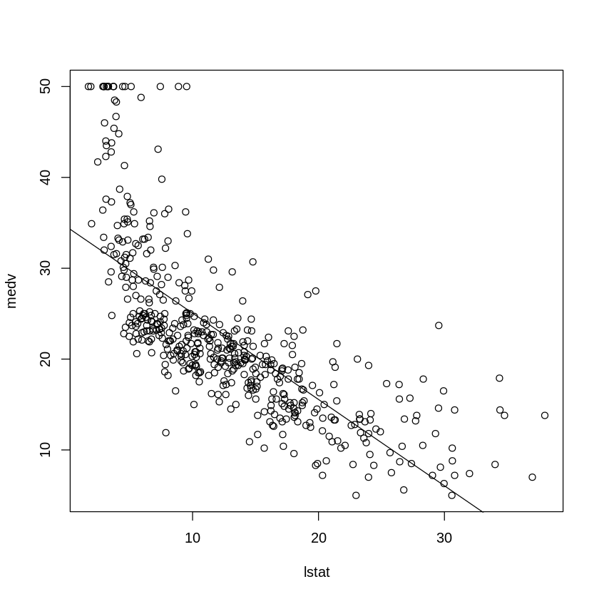

```r
plot(lstat ,medv)
abline(lm.fit)
```

به نظر می‌رسد رابطه‌ی بین lstat و medv در اینجا غیرخطی است. جلوتر به این مساله خواهیم پرداخت.  
با اعمال کردن $\texttt{plot()}$ مستقیما بر روی خروجی $\texttt{lm()}$ چهار نمودارِ تشخیصی رسم می‌شوند. در واقع این دستور یک نمودار را نمایش می‌دهد و با زدن دکمه‌ی enter می‌توان نمودار بعدی را مشاهده کرد. با استفاده از تابع $\texttt{par()}$ می‌توان هر چهار نمودار را با هم دید.

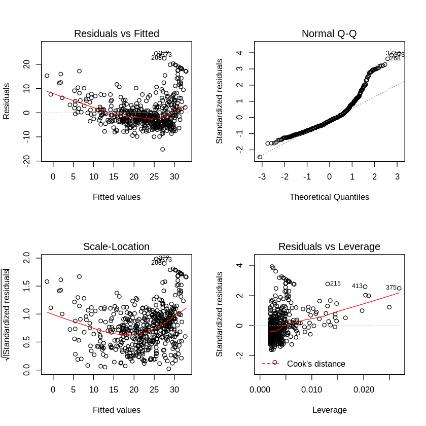

```r
## divides the plotting region into a 2 × 2 grid of panels
par(mfrow=c(2,2))
plot(lm.fit)
```

می‌توانیم انحراف‌‌های برازش یک رگرسیون خطی را با استفاده از تابع $\texttt{residuals()}$ محاسبه کنیم.

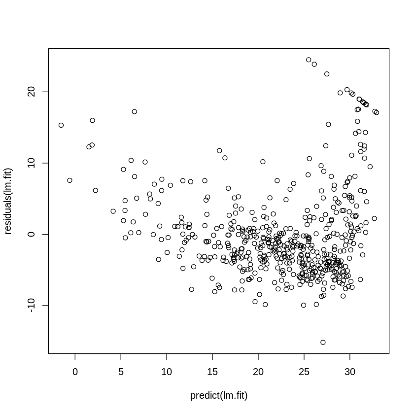

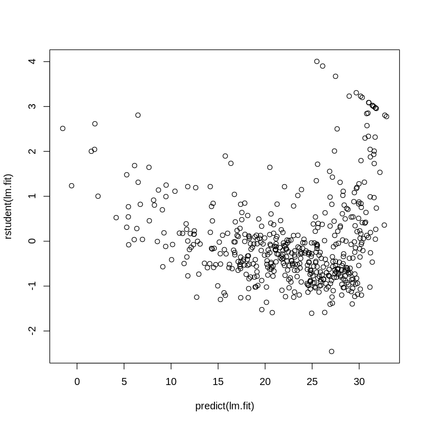

```r
plot(predict(lm.fit), residuals(lm.fit))
plot(predict(lm.fit), rstudent(lm.fit))
```

با مشاهده نمودارهای انحراف می‌توان به غیرخطی بودن رابطه پی برد.  
می‌توانیم با تابع $\texttt{hatvalues()}$ آماره‌های leverage را برای هر تعداد پیش‌بین محاسبه کنیم. تابع $\texttt{which.max()}$ اندیس بزرگترین عنصر یک بردار را مشخص می‌کند. در اینجا نشان می‌دهد که کدام مشاهده بزرگترین آماره‌ی leverage را داشته است:

**375:** 375

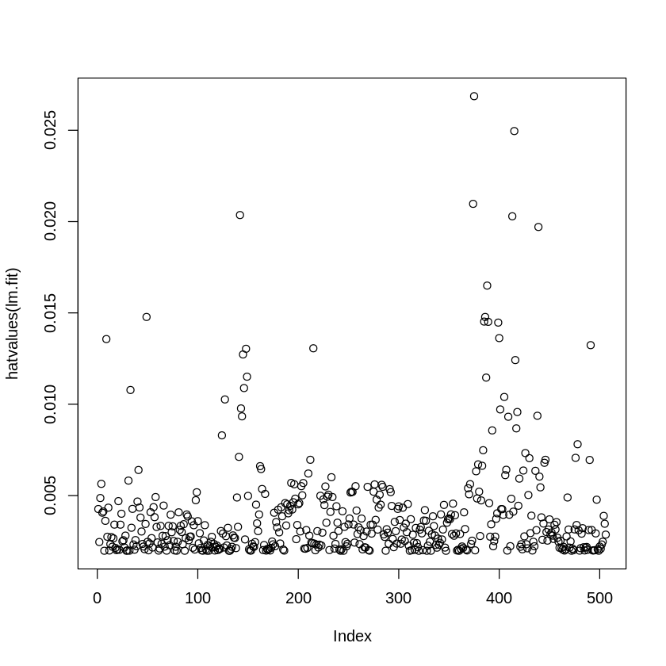

```r
plot(hatvalues (lm.fit))
which.max(hatvalues (lm.fit))
```

رگرسیون خطی چندتایی

برای برازش یک مدل با رگرسیون خطی چندتایی با استفاده از کمترین مربعات، مجددا از تابع $\texttt{lm()}$ استفاده می‌کنیم.

```r
## The syntax lm(y∼x1+x2+x3) is used to fit a model with three predictors, x1, x2, and x3.
lm.fit=lm(medv~lstat+age,data=Boston)
summary(lm.fit)
```

```
Call:
lm(formula = medv ~ lstat + age, data = Boston)

Residuals:
    Min      1Q  Median      3Q     Max
-15.981  -3.978  -1.283   1.968  23.158

Coefficients:
            Estimate Std. Error t value Pr(>|t|)
(Intercept) 33.22276    0.73085  45.458  < 2e-16 ***
lstat       -1.03207    0.04819 -21.416  < 2e-16 ***
age          0.03454    0.01223   2.826  0.00491 **
---
Signif. codes:  0 ‘***’ 0.001 ‘**’ 0.01 ‘*’ 0.05 ‘.’ 0.1 ‘ ’ 1

Residual standard error: 6.173 on 503 degrees of freedom
Multiple R-squared:  0.5513,	Adjusted R-squared:  0.5495
F-statistic:   309 on 2 and 503 DF,  p-value: < 2.2e-16
```

مجموعه داده‌ی Boston شامل ۱۳ متغیر می‌شود. برای سادگی نوشتار، می‌توان از سینکس زیر برای پیاده‌سازی رگرسیون با استفاده از تمامی این متغیرها استفاده کرد:

```r
lm.fit=lm(medv~.,data=Boston)
summary(lm.fit)
```

```
Call:
lm(formula = medv ~ ., data = Boston)

Residuals:
    Min      1Q  Median      3Q     Max
-15.595  -2.730  -0.518   1.777  26.199

Coefficients:
              Estimate Std. Error t value Pr(>|t|)
(Intercept)  3.646e+01  5.103e+00   7.144 3.28e-12 ***
crim        -1.080e-01  3.286e-02  -3.287 0.001087 **
zn           4.642e-02  1.373e-02   3.382 0.000778 ***
indus        2.056e-02  6.150e-02   0.334 0.738288
chas         2.687e+00  8.616e-01   3.118 0.001925 **
nox         -1.777e+01  3.820e+00  -4.651 4.25e-06 ***
rm           3.810e+00  4.179e-01   9.116  < 2e-16 ***
age          6.922e-04  1.321e-02   0.052 0.958229
dis         -1.476e+00  1.995e-01  -7.398 6.01e-13 ***
rad          3.060e-01  6.635e-02   4.613 5.07e-06 ***
tax         -1.233e-02  3.760e-03  -3.280 0.001112 **
ptratio     -9.527e-01  1.308e-01  -7.283 1.31e-12 ***
black        9.312e-03  2.686e-03   3.467 0.000573 ***
lstat       -5.248e-01  5.072e-02 -10.347  < 2e-16 ***
---
Signif. codes:  0 ‘***’ 0.001 ‘**’ 0.01 ‘*’ 0.05 ‘.’ 0.1 ‘ ’ 1

Residual standard error: 4.745 on 492 degrees of freedom
Multiple R-squared:  0.7406,	Adjusted R-squared:  0.7338
F-statistic: 108.1 on 13 and 492 DF,  p-value: < 2.2e-16
```

ما می‌توانیم به تک تک اجزای شیء summary با نام‌شان دسترسی پیدا کنیم ( دستور ?summary.lm را تایپ کنید تا موارد ممکن را ببینید).

```r
## gives us R^2
summary(lm.fit)$r.sq

## gives us RSE
summary(lm.fit)$sigma
```

0.74064266410941

4.74529818169963

مثالی از اجرای رگرسیون با همه‌ی متغیرها به غیر از یکی:

```r
lm.fit1=lm(medv~.-age,data=Boston)
summary(lm.fit1)
```

```
Call:
lm(formula = medv ~ . - age, data = Boston)

Residuals:
     Min       1Q   Median       3Q      Max
-15.6054  -2.7313  -0.5188   1.7601  26.2243

Coefficients:
              Estimate Std. Error t value Pr(>|t|)
(Intercept)  36.436927   5.080119   7.172 2.72e-12 ***
crim         -0.108006   0.032832  -3.290 0.001075 **
zn            0.046334   0.013613   3.404 0.000719 ***
indus         0.020562   0.061433   0.335 0.737989
chas          2.689026   0.859598   3.128 0.001863 **
nox         -17.713540   3.679308  -4.814 1.97e-06 ***
rm            3.814394   0.408480   9.338  < 2e-16 ***
dis          -1.478612   0.190611  -7.757 5.03e-14 ***
rad           0.305786   0.066089   4.627 4.75e-06 ***
tax          -0.012329   0.003755  -3.283 0.001099 **
ptratio      -0.952211   0.130294  -7.308 1.10e-12 ***
black         0.009321   0.002678   3.481 0.000544 ***
lstat        -0.523852   0.047625 -10.999  < 2e-16 ***
---
Signif. codes:  0 ‘***’ 0.001 ‘**’ 0.01 ‘*’ 0.05 ‘.’ 0.1 ‘ ’ 1

Residual standard error: 4.74 on 493 degrees of freedom
Multiple R-squared:  0.7406,	Adjusted R-squared:  0.7343
F-statistic: 117.3 on 12 and 493 DF,  p-value: < 2.2e-16
```

هم‌چنین از تابع $\texttt{update()}$ می‌توان استفاده کرد:

```r
lm.fit1=update(lm.fit, ~.-age)
```

روابط متقابل(interaction terms)

دستورِ lstat:black در R یک تقابل بین lstat و black ایجاد می‌کند. دستورِ lstat*age به طور همزمان lstat و age رابطه lstat×age را به عنوان پیش‌بین قرار می‌دهد (در واقع خلاصه شده‌ی عبارت lstat+age+lstat:age است)

```r
summary(lm(medv~lstat*age,data=Boston))
```

```
Call:
lm(formula = medv ~ lstat * age, data = Boston)

Residuals:
    Min      1Q  Median      3Q     Max
-15.806  -4.045  -1.333   2.085  27.552

Coefficients:
              Estimate Std. Error t value Pr(>|t|)
(Intercept) 36.0885359  1.4698355  24.553  < 2e-16 ***
lstat       -1.3921168  0.1674555  -8.313 8.78e-16 ***
age         -0.0007209  0.0198792  -0.036   0.9711
lstat:age    0.0041560  0.0018518   2.244   0.0252 *
---
Signif. codes:  0 ‘***’ 0.001 ‘**’ 0.01 ‘*’ 0.05 ‘.’ 0.1 ‘ ’ 1

Residual standard error: 6.149 on 502 degrees of freedom
Multiple R-squared:  0.5557,	Adjusted R-squared:  0.5531
F-statistic: 209.3 on 3 and 502 DF,  p-value: < 2.2e-16
```

تبدیل غیرخطی پیش‌بین‌ها

تابع $\texttt{lm()}$ می‌تواند با تبدیل‌های غیرخطی پیش‌بین‌ها استفاده شود. به طور مثال ما می‌توانیم با داشتن یک پیش‌بینِ X، یک پیش‌بینِ X<sup>2</sup> را با استفاده از $\text{I(X^2)}$ ساخت. به طور مثال:

```r
lm.fit2=lm(medv~lstat+I(lstat^2))
summary(lm.fit2)
```

```
Call:
lm(formula = medv ~ lstat + I(lstat^2))

Residuals:
     Min       1Q   Median       3Q      Max
-15.2834  -3.8313  -0.5295   2.3095  25.4148

Coefficients:
             Estimate Std. Error t value Pr(>|t|)
(Intercept) 42.862007   0.872084   49.15   <2e-16 ***
lstat       -2.332821   0.123803  -18.84   <2e-16 ***
I(lstat^2)   0.043547   0.003745   11.63   <2e-16 ***
---
Signif. codes:  0 ‘***’ 0.001 ‘**’ 0.01 ‘*’ 0.05 ‘.’ 0.1 ‘ ’ 1

Residual standard error: 5.524 on 503 degrees of freedom
Multiple R-squared:  0.6407,	Adjusted R-squared:  0.6393
F-statistic: 448.5 on 2 and 503 DF,  p-value: < 2.2e-16
```

```r
lm.fit=lm(medv~lstat)
anova(lm.fit ,lm.fit2)
```

| Res.Df | RSS | Df | Sum of Sq | F | Pr(>F) |
| --- | --- | --- | --- | --- | --- |
| 504 | 19472.38 | NA | NA | NA | NA |
| 503 | 15347.24 | 1 | 4125.138 | 135.1998 | 7.630116e-28 |

تابع $\texttt{anova()}$ در این جا یک آزمون فرض اجرا می‌کند که دو مدل را مقایسه کند. فرض صفر این است که دو مدل به یک اندازه بر داده منطبق می‌شوند و فرض دیگر این است که مدل دوم بهتر است.  
در اینجا F-statistic، عدد ۱۳۵ است و p-value مربوطه تقریبا صفر است. این به روشنی نشان می‌دهد که مدلی که شامل پیش‌بین‌های ‌‌lstat و lstat<sup>2</sup> می‌شود به مراتب برتر از مدلی‌‌ست که فقط پیش‌بینِ lstat را دارد. همان‌طور که پیش‌تر هم شواهدی از رابطه‌ای غیرخطی بین medv و lstat دیده بودیم.  
با استفاده از تابع $\texttt{poly()}$ می‌توان چندجمله‌ای‌هایی با درجات بالاتر را نیز به سادگی در $\texttt{lm()}$ ساخت. به طور مثال:

```r
## produces a fifth-order polynomial fit
lm.fit5=lm(medv~poly(lstat ,5))
summary(lm.fit5)
```

```
Call:
lm(formula = medv ~ poly(lstat, 5))

Residuals:
     Min       1Q   Median       3Q      Max
-13.5433  -3.1039  -0.7052   2.0844  27.1153

Coefficients:
                 Estimate Std. Error t value Pr(>|t|)
(Intercept)       22.5328     0.2318  97.197  < 2e-16 ***
poly(lstat, 5)1 -152.4595     5.2148 -29.236  < 2e-16 ***
poly(lstat, 5)2   64.2272     5.2148  12.316  < 2e-16 ***
poly(lstat, 5)3  -27.0511     5.2148  -5.187 3.10e-07 ***
poly(lstat, 5)4   25.4517     5.2148   4.881 1.42e-06 ***
poly(lstat, 5)5  -19.2524     5.2148  -3.692 0.000247 ***
---
Signif. codes:  0 ‘***’ 0.001 ‘**’ 0.01 ‘*’ 0.05 ‘.’ 0.1 ‘ ’ 1

Residual standard error: 5.215 on 500 degrees of freedom
Multiple R-squared:  0.6817,	Adjusted R-squared:  0.6785
F-statistic: 214.2 on 5 and 500 DF,  p-value: < 2.2e-16
```

مثالی از تبدیل غیرچندجمله‌ای:

```r
summary(lm(medv~log(rm),data=Boston))
```

```
Call:
lm(formula = medv ~ log(rm), data = Boston)

Residuals:
    Min      1Q  Median      3Q     Max
-19.487  -2.875  -0.104   2.837  39.816

Coefficients:
            Estimate Std. Error t value Pr(>|t|)
(Intercept)  -76.488      5.028  -15.21   <2e-16 ***
log(rm)       54.055      2.739   19.73   <2e-16 ***
---
Signif. codes:  0 ‘***’ 0.001 ‘**’ 0.01 ‘*’ 0.05 ‘.’ 0.1 ‘ ’ 1

Residual standard error: 6.915 on 504 degrees of freedom
Multiple R-squared:  0.4358,	Adjusted R-squared:  0.4347
F-statistic: 389.3 on 1 and 504 DF,  p-value: < 2.2e-16
```